# Capitulo 2 Networks

JRV

9/6/2020

## 2.1 Introducción

Formalmente, una gráfica es una estructura matemática que consiste de dos pares de objetos $G=(V,E)$. Un conjunto de vértices $V$ (también llamados nodos) y un conjunto de *aristas* $E$ (también llamados conexiones). Los elementos de $E$ son pares no ordenados $\{u,v\}$ (cuando no es relevante la “dirección” de la conexión)

```r
library(igraph)
library(sand)
```

Mostramos los índices de la gráfica

```r
g<- igraph::graph.formula(1-2, 1-3, 2-3, 2-4, 3-5, 4-5, 4-6, 4-7, 5-6, 6-7)
g
```

```
## IGRAPH ba8e7d2 UN-- 7 10 --
## + attr: name (v/c)
## + edges from ba8e7d2 (vertex names):
##  [1] 1--2 1--3 2--3 2--4 3--5 4--5 4--6 4--7 5--6 6--7
```

```r
V(g)
```

```
## + 7/7 vertices, named, from ba8e7d2:
## [1] 1 2 3 4 5 6 7
```

y las conexiones

```r
E(g)
```

```
## + 10/10 edges from ba8e7d2 (vertex names):
##  [1] 1--2 1--3 2--3 2--4 3--5 4--5 4--6 4--7 5--6 6--7
```

La misma información, en un formato más compacto.

```r
g
```

```
## IGRAPH ba8e7d2 UN-- 7 10 --
## + attr: name (v/c)
## + edges from ba8e7d2 (vertex names):
##  [1] 1--2 1--3 2--3 2--4 3--5 4--5 4--6 4--7 5--6 6--7
```

Una representación visual de la gráfica

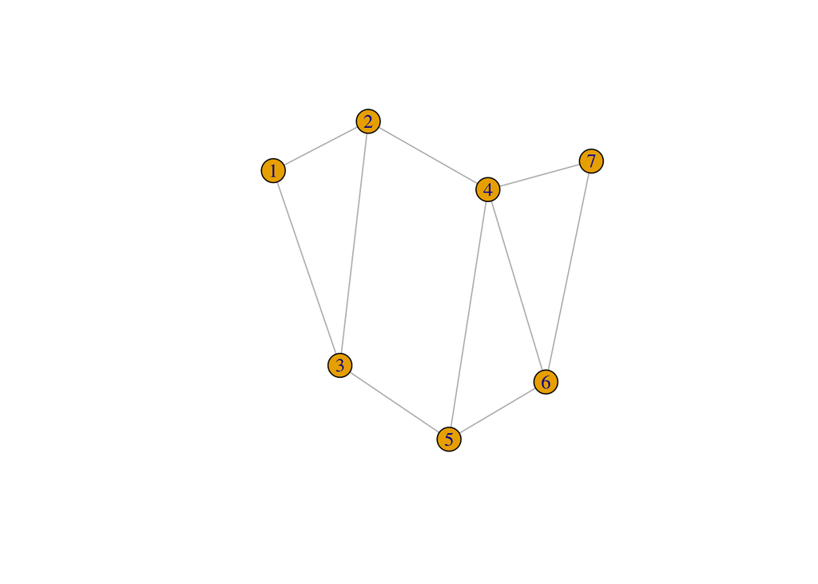

```r
plot(g)
```

Gráficas con ligas dirigidas son indicadas usando $+-$

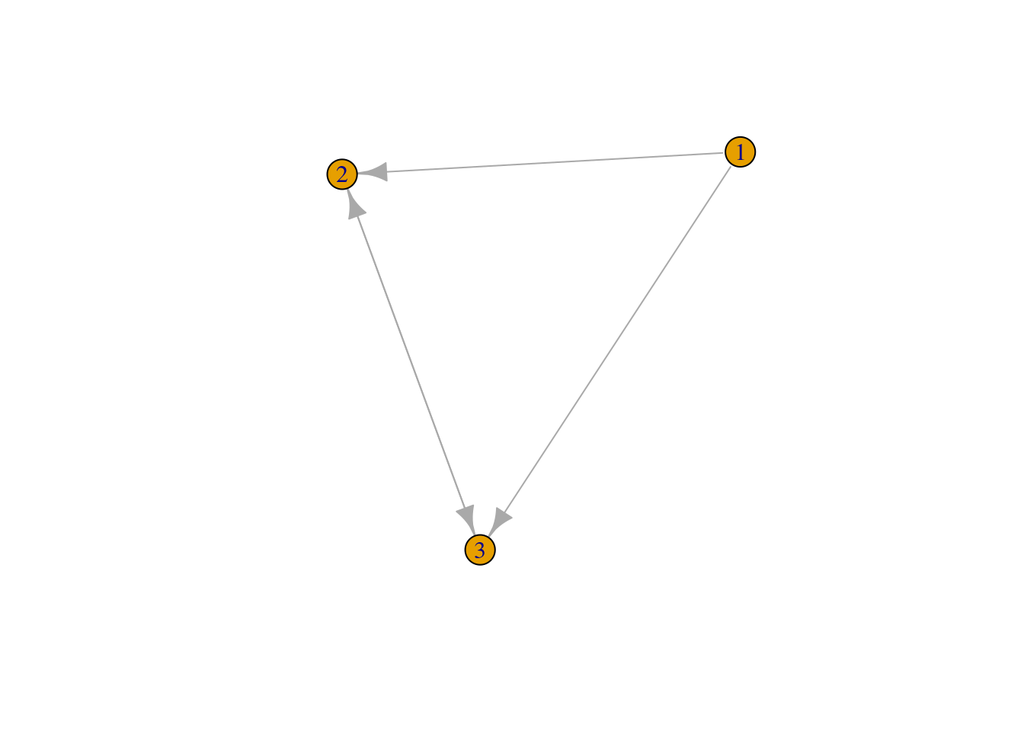

```r
dg <-igraph::graph.formula(1-+2, 1-+3, 2++3)
plot(dg)
```

Notamos que al definir las gráficas dirigidas o no dirigidas, se ha usado la convención usual en etiquetar de 1 a $N$. Las etiquetas pueden ser usadas en vez de la numeración usual

```r
dg2 <- igraph::graph.formula(Sam -+ Mary, Sam-+Tom, Mary++Tom)
dg2
```

```
## IGRAPH 771505a DN-- 3 4 --
## + attr: name (v/c)
## + edges from 771505a (vertex names):
## [1] Sam ->Mary Sam ->Tom  Mary->Tom  Tom ->Mary
```

De manera alternativa, las etiquetas de los vértices pueden ser cambiadas del etiquetado default, creado inicialmente.

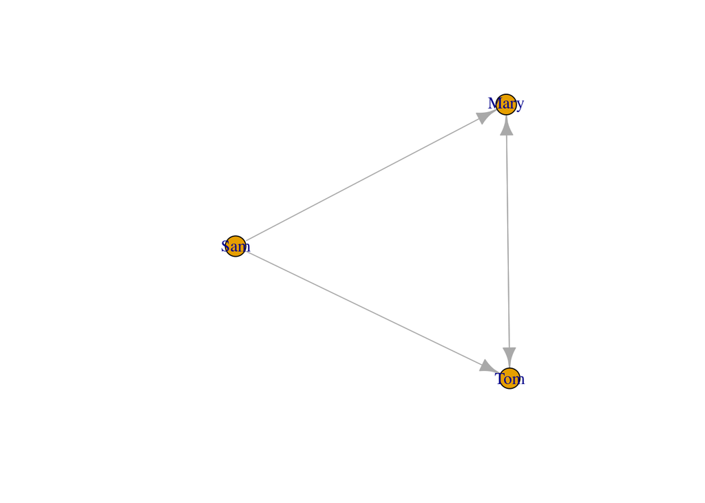

```r
V(dg2)$name <- c("Sam", "Mary", "Tom")
plot(dg2)
```

## Representación de las gráficas

La información para construir una red tipicamente es almacenada en un archivo. Al nvel más elemental existen 3 formatos básicos: listas de adyacencia, listas de nodos y matrices de adyacencia.

Una representación de una gráfica $G$ por su *lista* *de* *adyacencia* es un arreglo de tamaño $N$ en donde cada elemento de la lista contiene el conjunto de vértices $j$ para los cuales existe una liga/arista de $i$ a $j$. Una lista nodal o *lista* *de* *nodos* es una lista de dos columnas de todos los vértices que son ligados por un arco/liga.

```r
E(dg2)
```

```
## + 4/4 edges from 771505a (vertex names):
## [1] Sam ->Mary Sam ->Tom  Mary->Tom  Tom ->Mary
```

La función get.edgelist regresa una lista de conexiones como una matriz de 2 columnas.

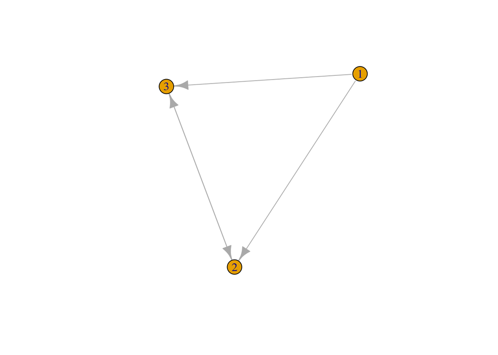

```r
plot(dg)
```

```r
get.edgelist(dg)
```

```
##      [,1] [,2]
## [1,] "1"  "2"
## [2,] "1"  "3"
## [3,] "2"  "3"
## [4,] "3"  "2"
```

```r
get.adjacency(dg)
```

```
## 3 x 3 sparse Matrix of class "dgCMatrix"
##   1 2 3
## 1 . 1 1
## 2 . . 1
## 3 . 1 .
```

### Operaciones en las gráficas

Operaciones sobre las gráficas a veces son necesarias. Por ejempplo

- Extraer parte de una gráfica.
- Eliminar algunos de sus vértices.
- Agregar nuevos vértices o
- Combinar múltiples gráficas.

La subgráfica **inducida** es una subgráfica $G'=(V',E')$ donde $V' \subset V$ es un subconjunto especificado de vértices y $E' \subseteq E$ es una colección de conexiones definidas por la gráfica $G$, entre los vértices de $E'$. Ejemplo: La gráfica $g$ esta definida por

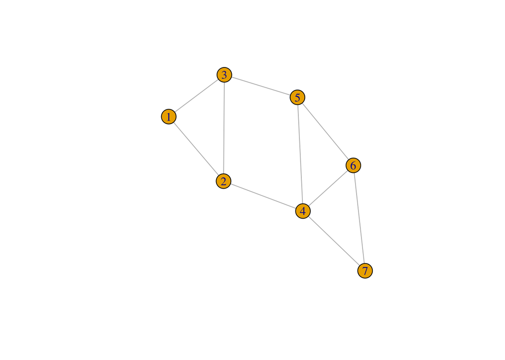

```r
plot(g)
```

```r
h <- induced.subgraph(g,1:5)
h
```

```
## IGRAPH dfe40ca UN-- 5 6 --
## + attr: name (v/c)
## + edges from dfe40ca (vertex names):
## [1] 1--2 1--3 2--3 2--4 3--5 4--5
```

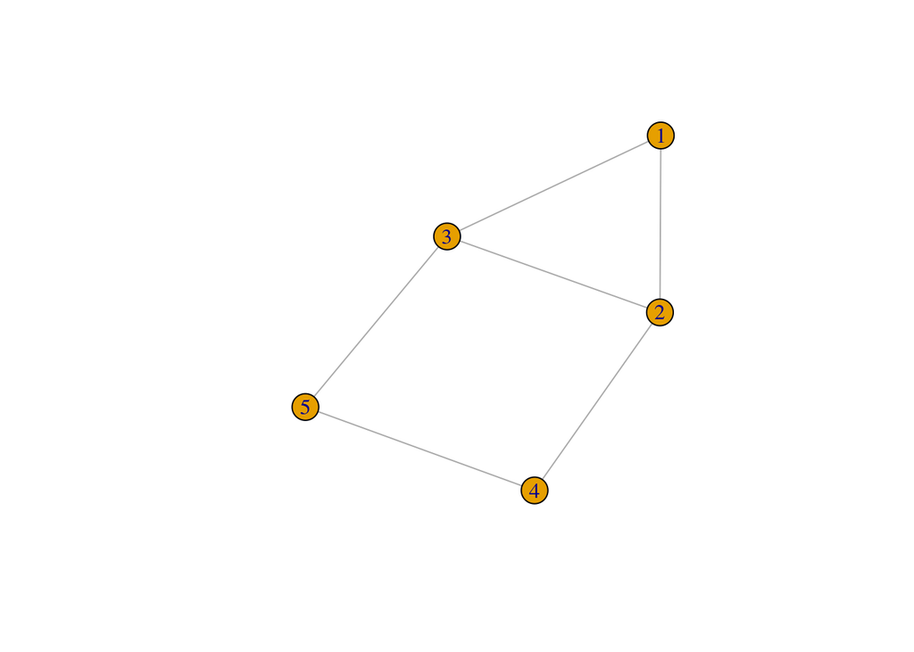

```r
plot(h)
```

La subgráfica $h$ puede ser construuida al quitar los vértices 6 y 7.

```r
h2 <- g - vertices(c(6,7))
h2
```

```
## IGRAPH 2229914 UN-- 5 6 --
## + attr: name (v/c)
## + edges from 2229914 (vertex names):
## [1] 1--2 1--3 2--3 2--4 3--5 4--5
```

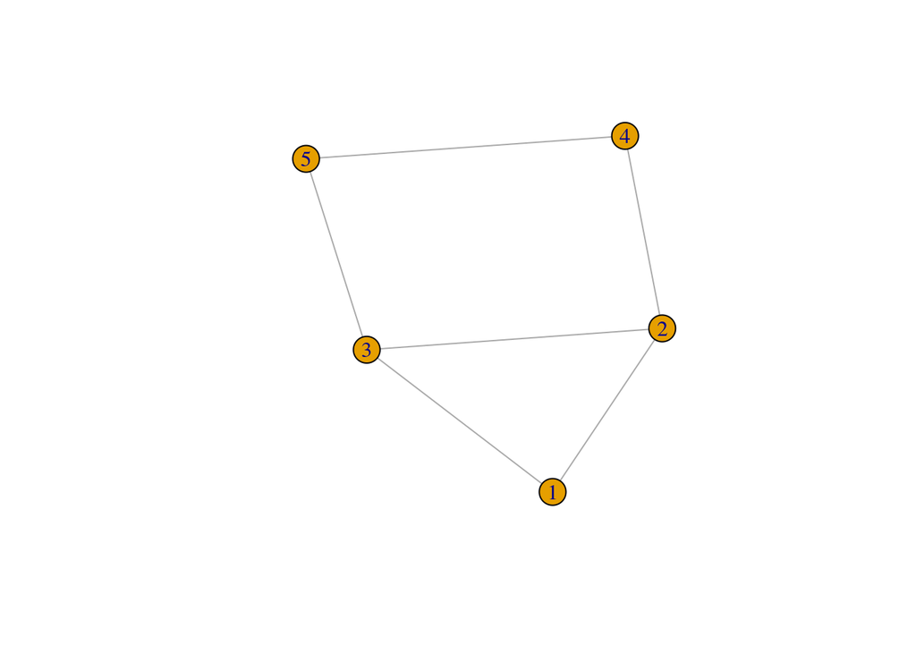

```r
plot(h2)
```

Finalmente, los conceptos conjuntistas de unión, unión disjunta, intersección, diferencia y complemento se extienden a gráficas. Por ejemplo, la unión de dos gráficas $H_1$ y $H_2$ es una gráfica cuyos vértices y conexiones son incluidas sí y solo sí estan en al menos una de las gráficas $H_1$ y $H-2$. Por ejemplo

```r
h1 <- h
#resto
h2 <-graph.formula(4-6, 4-7, 5-6, 6-7)
g <- graph.union(h1,h2)
g
```

```
## IGRAPH 55d6eb6 UN-- 7 10 --
## + attr: name (v/c)
## + edges from 55d6eb6 (vertex names):
##  [1] 6--7 5--6 4--7 4--6 4--5 3--5 2--4 2--3 1--3 1--2
```

Podemos acceder a atributos de las gráficas por medio del operador $\$$. Por ejemplo, para la gráfica de nombres

```r
V(dg2)$name
```

```
## [1] "Sam"  "Mary" "Tom"
```

```r
V(dg2)$gender <-c("M","F","M")
vertex_attr_names(dg2)
```

```
## [1] "name"   "gender"
```

## Usando dataframes

### Ejemplo.

Considere por ejemplo el dataset de abogados. El dataframe *elist.lazega* y las diversas variables atributos de los vértices, en el data frame *v.attr.lazega* se pueden combinar en un objeto gráfica de la siguiente forma

```r
library(sand)

grafica.lazega <- graph.data.frame(elist.lazega, directed = FALSE, vertices = v.attr.lazega)
##vemos que el comando define una gráfica o un objeto del tipo igraph
class(grafica.lazega)
```

```
## [1] "igraph"
```

```r
## Le agregamos otro atributo a los nodos o vértices
grafica.lazega$names <- "Lazega Lawyers"

vcount(grafica.lazega)
```

```
## [1] 36
```

```r
ecount(grafica.lazega)
```

```
## [1] 115
```

```r
##demas atributos
vertex_attr_names(grafica.lazega)
```

```
## [1] "name"      "Seniority" "Status"    "Gender"    "Office"    "Years"
## [7] "Age"       "Practice"  "School"
```

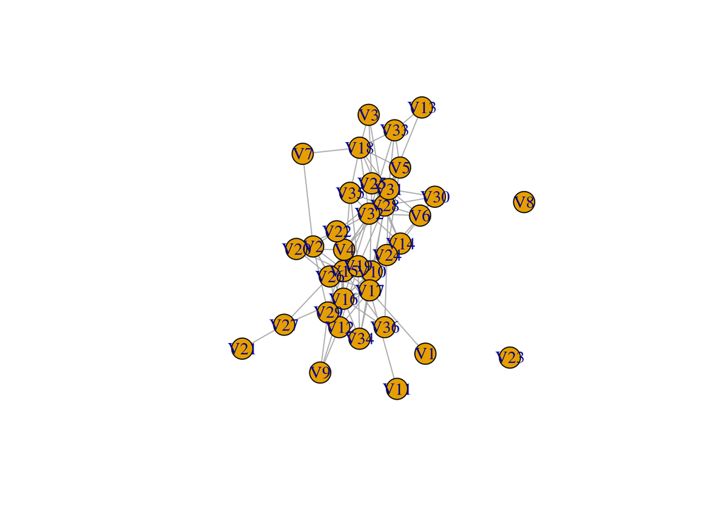

```r
## otra forma de revisar los atributos
latrr_lazega <-list.vertex.attributes(grafica.lazega)
plot(grafica.lazega)
```

## Otro ejemplo

[output not shown]

[output not shown]

[output not shown]

[output not shown]

Construimos la gráfica a partir de la matriz de adyacencia.

```r
G.coli <- graph_from_adjacency_matrix(regDB.adj,
                                      mode = "undirected")
class(G.coli)
```

```
## [1] "igraph"
```

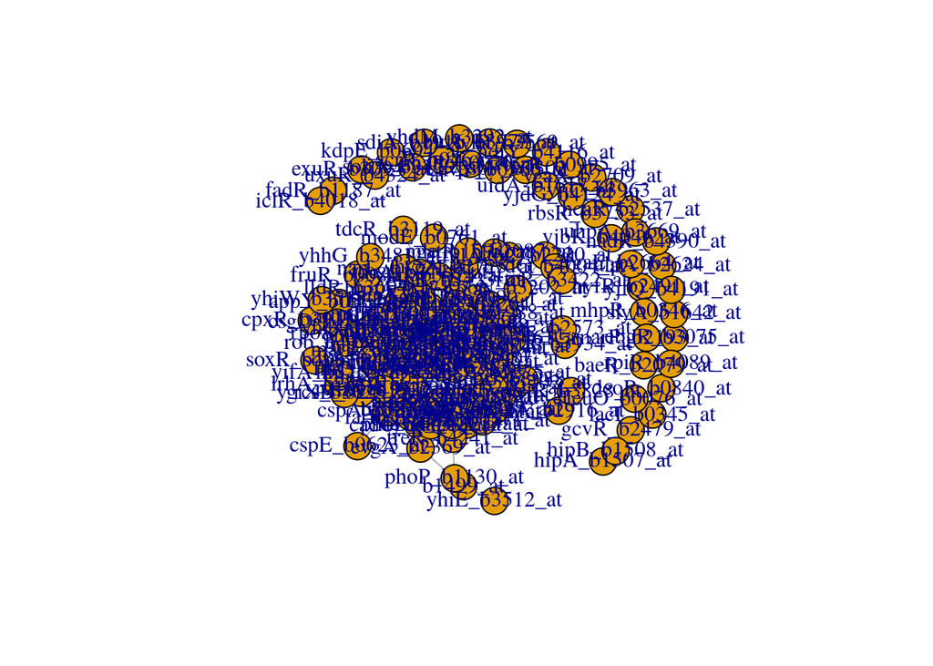

[output not shown]

[output not shown]

[output not shown]

[output not shown]

```r
plot(G.coli)
```